# Report of Random Forest Benchmark

DATA from https://www.kaggle.com/benhamner/random-forest-benchmark-r/data

載入library

```r
library(ggplot2)
library(randomForest)
```

讀取資料，並保留字串資料型態

```r
set.seed(1)
train <- read.csv("./all/train.csv", stringsAsFactors=FALSE)
test  <- read.csv("./all/test.csv",  stringsAsFactors=FALSE)
```

指派函數extractFeatures，輸出結果為fea。指派向量(“Pclass”,“Age”,“Sex”,“Parch”,“SibSp”,“Fare”,“Embarked”)為features。指派fea為變數資料中選擇features的結果。將-1指派為值為NA的fea$Age，fea$Fare的中位數指派為值為NA的fea$Fare，"S"指派為空值的fea$Embarked，將fea$Sex、fea$Embarked轉換為因子。

```r
extractFeatures <- function(data) {
  features <- c("Pclass",
                "Age",
                "Sex",
                "Parch",
                "SibSp",
                "Fare",
                "Embarked")
  fea <- data[,features]
  fea$Age[is.na(fea$Age)] <- -1
  fea$Fare[is.na(fea$Fare)] <- median(fea$Fare, na.rm=TRUE)
  fea$Embarked[fea$Embarked==""] = "S"
  fea$Sex      <- as.factor(fea$Sex)
  fea$Embarked <- as.factor(fea$Embarked)
  return(fea)
}
```

建構隨機森林模型，extractFeatures(train)作為模型變量，將train$Survived轉換為因子，隨機森林中的決策樹數目設定為100，計算各個變量在模型中的重要性。

```r
rf <- randomForest(extractFeatures(train), as.factor(train$Survived), ntree=100, importance=TRUE)
```

```r
submission <- data.frame(PassengerId = test$PassengerId)
submission$Survived <- predict(rf, extractFeatures(test))
write.csv(submission, file = "1_random_forest_r_submission.csv", row.names=FALSE)
```

計算rf的重要性，計算重要性的方法為type1，並將結果指派為imp。創造資料框featureImportance，內含Feature和Importance。

```r
imp <- importance(rf, type=1)
featureImportance <- data.frame(Feature=row.names(imp), Importance=imp[,1])
```

作長條圖，資料為featureImportance，x軸為Feature、Importance，y軸為Importance，對換座標軸、自訂x軸與y軸標籤，訂定標題Random Forest Feature Importance

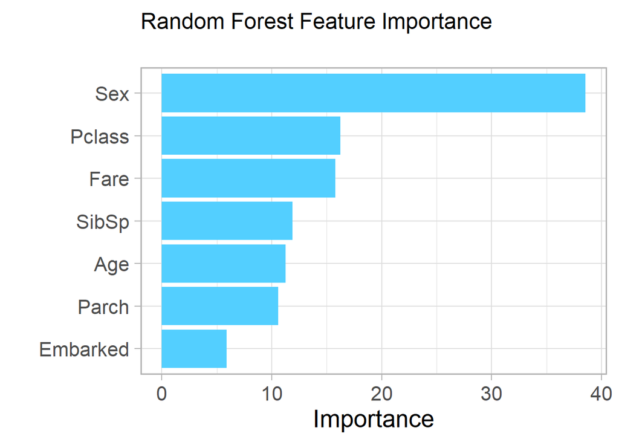

```r
ggplot(featureImportance, aes(x=reorder(Feature, Importance), y=Importance)) +
     geom_bar(stat="identity", fill="#53cfff") +
     coord_flip() +
     theme_light(base_size=20) +
     xlab("") +
     ylab("Importance") +
     ggtitle("Random Forest Feature Importance\n") +
     theme(plot.title=element_text(size=18))
```